# Pacific Salmon SAR & SAS Estimator

Background

This script uses WDFW hatchery coded wire tag (CWT) release and return data to calculate run-specific smolt-adult return (SAR), fit an SAR model, and calculate smolt-adult-survival (SAS) for Pacific salmon species. Tables are generated below that display user-specified parameters for query and analysis, location_code information associated with the query parameters set, release location for data incorporated in the SAR/SAS calculation, and the tag codes for fish included by brood year. The location_code information for associated systems/programs is based on a metadata ruleset constructed by the developers in conjunction with hatchery staff, and new queries will require additions to this ruleset for smooth data processing and model fitting.

CWT-based release and recovery data are pulled from the Pacific States Marine Fisheries Commission’s (PSMFC) Regional Marking Information System (RMIS) database. Release data are pulled for the query parameters set by the user (e.g., species, run, hatchery_location_code), categorized by stage-at-release (only smolts retained; method explained below), filtered for years of interest and CWT-tagged groups (i.e., tag_code_or_release_id beginning with “!” are removed), and then the tag codes remaining are used to pulled recovery data. An cwt_released column is created in the release data by combining cwt_1st_mark_count and cwt_2nd_mark_count, and julian day is calculated from first_release_date. Release counts (“cwt_released”) are then aggregated by run, brood year, release location, tag code, julian day, and weight-at-release. Tag code groups that do not have one of these data types are removed. The estimated number of recoveries (number_cwt_estimated) is reported by tag_code, so only grouped data are available. Release year and recovery year are used to calculate age-at-recovery, and this age is used to filter the recovery data for adults (e.g., age-3+ in Region 5). Release and return data are then paired and categorized by release size (i.e., length and weight), date, location, and coded-wire-tag codes. Together, these filtered release and recovery data are used to calculate fate-specific SARs. A table is generated below that reports the release_location_code information for the filtered data.

To ensure all data employed in SAR/SAS calculations are smolt-release data, releases are categorized by stage using RMIS data queried by the user and information reported in the literature. Quinn (2018) reports length-at-smolt (mm) by species in Table 15.1, which summarizes data from 218 published and unpublished reports. We use these reported values to inform a release stage designation, where the avg_length and avg_weight fields queried are fit to an exponential model and the model fit is used to predict weight-at-smolt. This weight-at-smolt is then used to classify release stages, currently implemented as “smolt” if they are larger than the threshold size calculated or “fry_parr” if smaller than it. Given the query-specific nature of this analysis, if program- or system-specific data on size-at-smolt were available, those data could be used directly to inform release_stage classifications.

**Query Parameters**

Table 1: Parameter values set in the YAML header defining which data are being pulled from RMIS for calculation of SAR and SAS.

| params | value |
| --- | --- |
| system | r5_cowlitz |
| species | 1 |
| run | 3 |
| adult_age | 3 |
| start_yr | 2000 |
| end_yr | 2026 |

**Location code ruleset**

Table 2: Hatchery, stock, and release location information for the query parameters set by the user.

| species | run | loc_code | loc_col | name | region | system |
| --- | --- | --- | --- | --- | --- | --- |
| 1 | 3 | 3F42001^^260002^H02 | hatchery_location_code | COWLITZ SALMON HATCHERY | 5 | r5_cowlitz |
| 1 | 3 | 3F42001^^260002^R | release_location_code | COWLITZ R 26.0002 | 5 | r5_cowlitz |
| 1 | 3 | 3F42001^^260002^R07 | release_location_code | COWLITZ R @ MAYFIELD | 5 | r5_cowlitz |

**Release locations**

Table 3: Release location information for pulled RMIS data after filtering for ruleset locations to be used in the following smolt-adult return calculations.

| loc_code | Count | name |
| --- | --- | --- |
| 3F42001^^260002^R | 755 | COWLITZ R 26.0002 |
| 3F42001^^260002^R07 | 2 | COWLITZ R @ MAYFIELD |

**CWT Codes & Tag Rates**

Table 4: Tag codes and calcualted tagging rates for released fish by brood year that are included in the following analysis.

| species | brood_year | hatchery_location_code | first_release_date_month | tag_code | cwt_released | total_released | tag_rate |
| --- | --- | --- | --- | --- | --- | --- | --- |
| 1 | 2000 | 3F42001^^260002^H02 | 5 | 630673 | 200124 | 2950883 | 0.0678183 |
| 1 | 2001 | 3F42001^^260002^H02 | 6 | 631379 | 209732 | 5303871 | 0.0395432 |
| 1 | 2002 | 3F42001^^260002^H02 | 6 | 631782 | 200134 | 5215558 | 0.0383725 |
| 1 | 2003 | 3F42001^^260002^H02 | 6 | 632573 | 198549 | 5016495 | 0.0395792 |
| 1 | 2004 | 3F42001^^260002^H02 | 6 | 633075 | 194734 | 5201338 | 0.0374392 |
| 1 | 2005 | 3F42001^^260002^H02 | 6 | 633287 | 178376 | 4758152 | 0.0374885 |
| 1 | 2006 | 3F42001^^260002^H02 | 6 | 633877 | 202114 | 4678192 | 0.0432034 |
| 1 | 2007 | 3F42001^^260002^H02 | 6 | 634280 | 202953 | 4246647 | 0.0477914 |
| 1 | 2008 | 3F42001^^260002^H02 | 6 | 634279 | 201327 | 5104829 | 0.0394385 |
| 1 | 2009 | 3F42001^^260002^H02 | 6 | 635286 | 197505 | 5077356 | 0.0388992 |
| 1 | 2010 | 3F42001^^260002^H02 | 6 | 635694 | 203636 | 4405456 | 0.0462236 |
| 1 | 2011 | 3F42001^^260002^H02 | 6 | 636093 | 200966 | 4494944 | 0.0447093 |
| 1 | 2012 | 3F42001^^260002^H02 | 6 | 636490 | 200131 | 1519271 | 0.1317283 |
| 1 | 2013 | 3F42001^^260002^H02 | 6 | 636270 | 102600 | 3153131 | 0.0325391 |
| 1 | 2013 | 3F42001^^260002^H02 | 6 | 636655 | 221849 | 3153131 | 0.0703583 |
| 1 | 2013 | 3F42001^^260002^H02 | 6 | 636656 | 219871 | 3153131 | 0.0697310 |
| 1 | 2013 | 3F42001^^260002^H02 | 6 | 636657 | 220764 | 3153131 | 0.0700142 |
| 1 | 2013 | 3F42001^^260002^H02 | 6 | 636658 | 215658 | 3153131 | 0.0683949 |
| 1 | 2013 | 3F42001^^260002^H02 | 6 | 636668 | 219331 | 3153131 | 0.0695597 |
| 1 | 2014 | 3F42001^^260002^H02 | 5 | 636793 | 100505 | 3447633 | 0.0291519 |
| 1 | 2014 | 3F42001^^260002^H02 | 5 | 636821 | 208628 | 3447633 | 0.0605134 |
| 1 | 2014 | 3F42001^^260002^H02 | 5 | 636838 | 890399 | 3447633 | 0.2582639 |
| 1 | 2015 | 3F42001^^260002^H02 | 5 | 636921 | 84324 | 1894965 | 0.0444990 |
| 1 | 2015 | 3F42001^^260002^H02 | 6 | 636969 | 1093023 | 1521124 | 0.7185627 |
| 1 | 2016 | 3F42001^^260002^H02 | 6 | 637153 | 101357 | 2894928 | 0.0350119 |
| 1 | 2016 | 3F42001^^260002^H02 | 6 | 637189 | 995614 | 2894928 | 0.3439167 |
| 1 | 2017 | 3F42001^^260002^H02 | 6 | 637242 | 219592 | 3274631 | 0.0670585 |
| 1 | 2017 | 3F42001^^260002^H02 | 6 | 637341 | 100804 | 3274631 | 0.0307833 |
| 1 | 2017 | 3F42001^^260002^H02 | 6 | 637383 | 612815 | 3274631 | 0.1871402 |
| 1 | 2017 | 3F42001^^260002^H02 | 6 | 637403 | 566006 | 3274631 | 0.1728457 |
| 1 | 2018 | 3F42001^^260002^H02 | 6 | 637381 | 522954 | 1755813 | 0.2978415 |
| 1 | 2018 | 3F42001^^260002^H02 | 6 | 637527 | 455936 | 1755813 | 0.2596723 |
| 1 | 2018 | 3F42001^^260002^H02 | 6 | 637606 | 659373 | 1755813 | 0.3755371 |
| 1 | 2019 | 3F42001^^260002^H02 | 6 | 637769 | 21001 | 1023762 | 0.0205136 |
| 1 | 2019 | 3F42001^^260002^H02 | 6 | 637779 | 103769 | 1023762 | 0.1013605 |
| 1 | 2020 | 3F42001^^260002^H02 | 6 | 637983 | 13058 | 3596659 | 0.0036306 |
| 1 | 2020 | 3F42001^^260002^H02 | 6 | 637984 | 13150 | 3596659 | 0.0036562 |
| 1 | 2020 | 3F42001^^260002^H02 | 6 | 637985 | 12827 | 3596659 | 0.0035664 |
| 1 | 2020 | 3F42001^^260002^H02 | 6 | 637986 | 13028 | 3596659 | 0.0036223 |
| 1 | 2020 | 3F42001^^260002^H02 | 6 | 637987 | 13114 | 3596659 | 0.0036462 |
| 1 | 2020 | 3F42001^^260002^H02 | 6 | 637988 | 13091 | 3596659 | 0.0036398 |
| 1 | 2020 | 3F42001^^260002^H02 | 6 | 637989 | 13197 | 3596659 | 0.0036692 |
| 1 | 2020 | 3F42001^^260002^H02 | 6 | 637990 | 13170 | 3596659 | 0.0036617 |
| 1 | 2020 | 3F42001^^260002^H02 | 6 | 637991 | 12943 | 3596659 | 0.0035986 |
| 1 | 2021 | 3F42001^^260002^H02 | 4 | 637294 | 3024 | 19482 | 0.1552202 |
| 1 | 2021 | 3F42001^^260002^H02 | 4 | 637298*1 | 3317 | 19482 | 0.1702597 |
| 1 | 2021 | 3F42001^^260002^H02 | 4 | 637409*1 | 4024 | 19482 | 0.2065496 |
| 1 | 2021 | 3F42001^^260002^H02 | 4 | 637815*1 | 5029 | 19482 | 0.2581357 |
| 1 | 2021 | 3F42001^^260002^H02 | 4 | 637819*1 | 3374 | 19482 | 0.1731855 |
| 1 | 2021 | 3F42001^^260002^H02 | 4 | 637820*1 | 599 | 19482 | 0.0307463 |
| 1 | 2021 | 3F42001^^260002^H02 | 4 | 638086*1 | 115 | 19482 | 0.0059029 |
| 1 | 2021 | 3F42001^^260002^H02 | 5 | 638334 | 15765 | 3503839 | 0.0044994 |
| 1 | 2021 | 3F42001^^260002^H02 | 5 | 638335 | 15858 | 3503839 | 0.0045259 |
| 1 | 2021 | 3F42001^^260002^H02 | 5 | 638336 | 15780 | 3503839 | 0.0045036 |
| 1 | 2021 | 3F42001^^260002^H02 | 5 | 638337 | 15802 | 3503839 | 0.0045099 |
| 1 | 2021 | 3F42001^^260002^H02 | 5 | 638338 | 15734 | 3503839 | 0.0044905 |
| 1 | 2021 | 3F42001^^260002^H02 | 5 | 638339 | 15827 | 3503839 | 0.0045170 |
| 1 | 2021 | 3F42001^^260002^H02 | 5 | 638340 | 15808 | 3503839 | 0.0045116 |
| 1 | 2021 | 3F42001^^260002^H02 | 5 | 638341 | 15817 | 3503839 | 0.0045142 |
| 1 | 2022 | 3F42001^^260002^H02 | 4 | 638432*1 | 7045 | 7045 | 1.0000000 |
| 1 | 2022 | 3F42001^^260002^H02 | 6 | 638457 | 127968 | 1187707 | 0.1077437 |
| 1 | 2023 | 3F42001^^260002^H02 | 6 | 638608 | 124184 | 964251 | 0.1287880 |
| 1 | 2024 | 3F42001^^260002^H02 | 6 | 639088 | 126883 | 1613481 | 0.0786393 |
| 1 | 2025 | 3F42001^^260002^H02 | 5 | 638798 | 200231 | 1660101 | 0.1206137 |

**FPP Conversion**

Table 5: Conversion table for fish-per-pound to grams-per-fish.

| fpp | gpf |
| --- | --- |
| 1 | 454 |
| 5 | 90 |
| 10 | 45 |
| 20 | 23 |
| 30 | 15 |
| 40 | 11 |
| 50 | 9 |
| 100 | 5 |

[interactive chart not shown]

Figure 1: Length-weight relationship used to determine weight-at-smolt via reported lenght-at-smolt (Quinn, 2018). The red-dashed vertical line shows the species-specific size used for the weight-at-smolt conversion. Facets are split by run, and outliers are removed before model fitting and prediction.

References

Independent Scientific Advisory Board (ISAB). 2025. Challenges and opportunities for improved estimation, interpretation, and use of smolt-to-adult return (SAR) and survival (SAS) metrics for salmon and steelhead in the Columbia River Basin. Report ISAB 2025-1. Northwest Power and Conservation Council, Portland, Oregon.

Quinn, T.P. 2018. The behavior and ecology of Pacific salmon and trout. Second Edition. University of Washington Press. ISBN: 9780295743332.

Smolt-adult-return (SAR)

Smolt-adult-return is calculated for each categorized fate (i.e., hatchery, fishery, and spawning ground) of paired release-recovery data. Below, fate is categorized based on fishery coding, and then fate-specific SARs are reported. These fate-specific SARs are then used below to fit predictive SAR models, and calculate smolt-adult-survival (SAS). Fate is determined by the fishery coding reported for each recovery. Fishery codes range from 10-99, with some additional codes supplied for high seas fishery categories (800-812). Troll (10-19), net & seine (20-29), aboriginal (30-39), sport (40-49), treaty subsitence (56), test (60-69), and high seas (80-89, 800, 802-805, 812) fisheries recoveries are designated as ‘fishery’ fates. In addition, hatchery (50), fish trap (52), broodstock collections (53), and mixed broodstock collection/hatchery returns (57) recoveries are designated as ‘hatchery’ fates, and spawning ground (54) recoveries are designated as ‘spawngr’ fates.

After fate classification, paired release-recovery data are then used to calculate fate-specific SARs. The recovery_location_codes present in the filtered data and the estimated recoveries (number_cwt_estimated) for each recovery location are reported below. There will likely be strays present, but a ‘return to rack’ is desired for the hatchery to inform program performance and broodstock collection. Therefore, these stray fish are filtered out here and will be re-incorporated in a ‘stray’ fate module in later development. Therefore, all hatchery SAR results will be for the list of location_codes categorized as hatchery_location_code in the metadata ruleset from the Setup page. Hatcheries will often vary their rearing treatments to produce fish of different sizes at release or to release fish at different times of the season. Here, we aggregate the filtered hatchery data by the treatment variables size-at-release, release month, release site, and julian day of release. Figures and tables are displayed below to summarize the results.

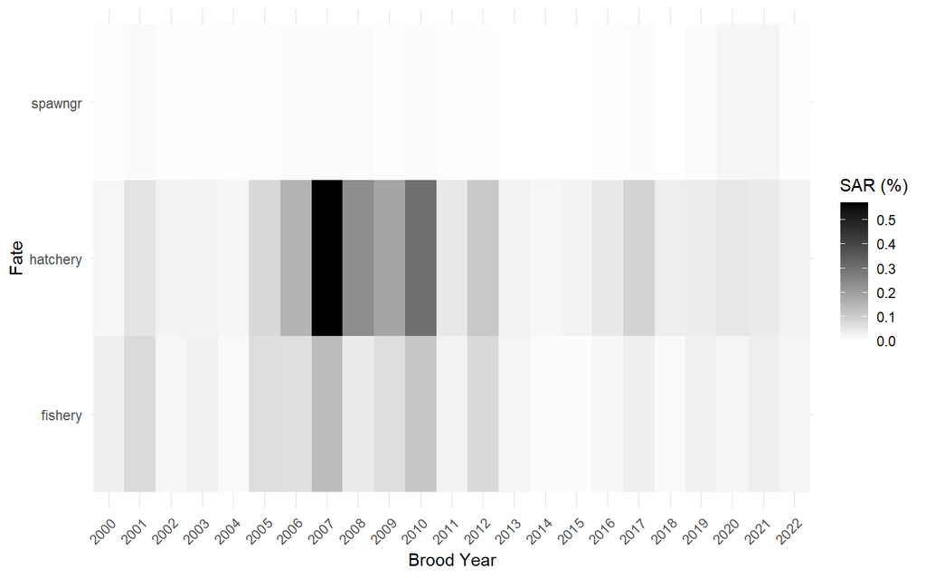

Figure 2: Smolt-adult return calculated collectively across brood year released and recovery fate.

**Hatchery Rec**

Table 6: Recovery locations associated with a ‘hatchery’ fate in the filtered data, and the number of estimated recoveries reported for each recovery location.

| recovery_location_code | name | latitude | longitude | psc_region | recoveries |
| --- | --- | --- | --- | --- | --- |
| **2000** |  |  |  |  |  |
| 3F42001^^260002^H02 | COWLITZ SALMON HATCHERY | 46.5113 | -122.6293 | LOCR | 553.684999 |
| **2001** |  |  |  |  |  |
| 3F42001^^260002^H02 | COWLITZ SALMON HATCHERY | 46.5113 | -122.6293 | LOCR | 2844.484438 |
| 3F42001^^270002^H | KALAMA FALLS HATCHERY | 46.0160 | -122.7336 | LOCR | 28.829234 |
| **2002** |  |  |  |  |  |
| 3F42001^^260002^H02 | COWLITZ SALMON HATCHERY | 46.5113 | -122.6293 | LOCR | 1343.931196 |
| **2003** |  |  |  |  |  |
| 3F42001^^260002^H02 | COWLITZ SALMON HATCHERY | 46.5113 | -122.6293 | LOCR | 1209.978119 |
| **2004** |  |  |  |  |  |
| 3F42001^^260002^H02 | COWLITZ SALMON HATCHERY | 46.5113 | -122.6293 | LOCR | 1035.812378 |
| **2005** |  |  |  |  |  |
| 3F42001^^260002^H02 | COWLITZ SALMON HATCHERY | 46.5113 | -122.6293 | LOCR | 3613.374388 |
| 3F42001^^270002^H | KALAMA FALLS HATCHERY | 46.0160 | -122.7336 | LOCR | 84.292507 |
| 3F42001^^270168^R03 | MERWIN DAM FCF | 45.9570 | -122.5561 | LOCR | 26.674844 |
| **2006** |  |  |  |  |  |
| 3F42001^^260002^H02 | COWLITZ SALMON HATCHERY | 46.5113 | -122.6293 | LOCR | 7066.335017 |
| 3F42001^^270002^H | KALAMA FALLS HATCHERY | 46.0160 | -122.7336 | LOCR | 168.273627 |
| 3F42001^^270168^R03 | MERWIN DAM FCF | 45.9570 | -122.5561 | LOCR | 23.146304 |
| **2007** |  |  |  |  |  |
| 3F42001^^260002^H02 | COWLITZ SALMON HATCHERY | 46.5113 | -122.6293 | LOCR | 24155.207182 |
| 3F42001^^270002^H | KALAMA FALLS HATCHERY | 46.0160 | -122.7336 | LOCR | 154.421245 |
| **2008** |  |  |  |  |  |
| 3F42001^^260002^H02 | COWLITZ SALMON HATCHERY | 46.5113 | -122.6293 | LOCR | 12059.523664 |
| 3F42001^^270002^H | KALAMA FALLS HATCHERY | 46.0160 | -122.7336 | LOCR | 29.159295 |
| **2009** |  |  |  |  |  |
| 3F42001^^260002^H02 | COWLITZ SALMON HATCHERY | 46.5113 | -122.6293 | LOCR | 9365.492339 |
| 3F42001^^270002^H | KALAMA FALLS HATCHERY | 46.0160 | -122.7336 | LOCR | 78.664891 |
| **2010** |  |  |  |  |  |
| 3F42001^^260002^H02 | COWLITZ SALMON HATCHERY | 46.5113 | -122.6293 | LOCR | 13240.641319 |

[output cut: 57 more lines]

**Spawngr Rec**

Table 7: Recovery locations associated with a ‘spawngr’ fate in the filtered data, and the number of estimated recoveries reported for each recovery location.

| recovery_location_code | name | latitude | longitude | psc_region | recoveries |
| --- | --- | --- | --- | --- | --- |
| **2000** |  |  |  |  |  |
| 3F42001^^260002^R | COWLITZ R 26.0002 | 46.0956 | -122.9155 | LOCR | 32.292148 |
| 3F42001^^270168^R01 | LEWIS R -NF 27.0168 | 45.8504 | -122.7824 | LOCR | 107.345587 |
| **2001** |  |  |  |  |  |
| 3F42001^^260002^R | COWLITZ R 26.0002 | 46.0956 | -122.9155 | LOCR | 520.443543 |
| 3F42001^^270168^R01 | LEWIS R -NF 27.0168 | 45.8504 | -122.7824 | LOCR | 40.462083 |
| **2002** |  |  |  |  |  |
| 3F42001^^260002^R | COWLITZ R 26.0002 | 46.0956 | -122.9155 | LOCR | 110.495797 |
| **2003** |  |  |  |  |  |
| 3F42001^^260002^R | COWLITZ R 26.0002 | 46.0956 | -122.9155 | LOCR | 183.934865 |
| **2004** |  |  |  |  |  |
| 3F42001^^260002^R | COWLITZ R 26.0002 | 46.0956 | -122.9155 | LOCR | 81.198289 |
| **2005** |  |  |  |  |  |
| 3F42001^^260002^R | COWLITZ R 26.0002 | 46.0956 | -122.9155 | LOCR | 67.487356 |
| 3F42001^^270002^R | KALAMA R 27.0002 | 46.0338 | -122.8746 | LOCR | 88.560483 |
| **2006** |  |  |  |  |  |
| 3F42001^^260002^R | COWLITZ R 26.0002 | 46.0956 | -122.9155 | LOCR | 153.228530 |
| 3F42001^^270168^R01 | LEWIS R -NF 27.0168 | 45.8504 | -122.7824 | LOCR | 215.723549 |
| **2007** |  |  |  |  |  |
| 3F42001^^260002^R | COWLITZ R 26.0002 | 46.0956 | -122.9155 | LOCR | 238.955368 |
| 3F42001^^270168^R01 | LEWIS R -NF 27.0168 | 45.8504 | -122.7824 | LOCR | 37.245232 |
| 3F42001^^280159^R | WASHOUGAL R 28.0159 | 45.5734 | -122.3962 | LOCR | 89.974438 |
| **2008** |  |  |  |  |  |
| 3F42001^^260002^R | COWLITZ R 26.0002 | 46.0956 | -122.9155 | LOCR | 412.287073 |
| **2009** |  |  |  |  |  |
| 3F42001^^260002^R | COWLITZ R 26.0002 | 46.0956 | -122.9155 | LOCR | 156.558558 |
| 3F42001^^270168^R01 | LEWIS R -NF 27.0168 | 45.8504 | -122.7824 | LOCR | 64.268702 |
| **2010** |  |  |  |  |  |
| 3F42001^^260002^R | COWLITZ R 26.0002 | 46.0956 | -122.9155 | LOCR | 59.709769 |
| 3F42001^^260535^R | MILL CR 26.0535 | 46.5160 | -122.6368 | LOCR | 119.419538 |
| 3F42001^^270168^R01 | LEWIS R -NF 27.0168 | 45.8504 | -122.7824 | LOCR | 155.548276 |
| **2011** |  |  |  |  |  |
| 3F42001^^270168^R01 | LEWIS R -NF 27.0168 | 45.8504 | -122.7824 | LOCR | 79.849079 |
| **2012** |  |  |  |  |  |
| 3F42001^^270168^R | LEWIS R 27.0168 | 45.8504 | -122.7824 | LOCR | 13.209006 |
| 3F42001^^270168^R01 | LEWIS R -NF 27.0168 | 45.8504 | -122.7824 | LOCR | 27.101236 |
| **2014** |  |  |  |  |  |
| 3F42001^^260002^R | COWLITZ R 26.0002 | 46.0956 | -122.9155 | LOCR | 15.333156 |
| **2015** |  |  |  |  |  |
| 3F42001^^270168^R | LEWIS R 27.0168 | 45.8504 | -122.7824 | LOCR | 3.173001 |
| **2016** |  |  |  |  |  |
| 3F42001^^260002^R | COWLITZ R 26.0002 | 46.0956 | -122.9155 | LOCR | 53.850254 |
| 3F42001^^270168^R | LEWIS R 27.0168 | 45.8504 | -122.7824 | LOCR | 23.464986 |
| **2017** |  |  |  |  |  |
| 3F42001^^260002^R | COWLITZ R 26.0002 | 46.0956 | -122.9155 | LOCR | 568.662541 |
| 3F42001^^260535^R | MILL CR 26.0535 | 46.5160 | -122.6368 | LOCR | 49.481627 |
| 3F42001^^270002^R | KALAMA R 27.0002 | 46.0338 | -122.8746 | LOCR | 45.930013 |
| 3F42001^^270168^R | LEWIS R 27.0168 | 45.8504 | -122.7824 | LOCR | 18.802894 |
| **2018** |  |  |  |  |  |
| 3F42001^^260002^R | COWLITZ R 26.0002 | 46.0956 | -122.9155 | LOCR | 37.015814 |
| 3F42001^^270168^R | LEWIS R 27.0168 | 45.8504 | -122.7824 | LOCR | 9.770790 |
| **2019** |  |  |  |  |  |
| 3F42001^^260002^R | COWLITZ R 26.0002 | 46.0956 | -122.9155 | LOCR | 69.060452 |
| **2020** |  |  |  |  |  |
| 3F42001^^260002^R | COWLITZ R 26.0002 | 46.0956 | -122.9155 | LOCR | 1652.712878 |
| 3F42001^^270168^R | LEWIS R 27.0168 | 45.8504 | -122.7824 | LOCR | 1122.324402 |
| **2021** |  |  |  |  |  |
| 3F42001^^260002^R | COWLITZ R 26.0002 | 46.0956 | -122.9155 | LOCR | 1394.426784 |
| **2022** |  |  |  |  |  |
| 3F42001^^260002^R | COWLITZ R 26.0002 | 46.0956 | -122.9155 | LOCR | 30.813854 |

**Fishery Rec**

Table 8: Recovery locations associated with a ‘fishery’ fate in the filtered data, and the number of estimated recoveries reported for each recovery location.

| recovery_location_code | name | psc_basin | fishery_short_name | recoveries | water_type | state_name | fishery_type |
| --- | --- | --- | --- | --- | --- | --- | --- |
| **2000** |  |  |  |  |  |  |  |
| 1M1NW113^41 | AK M 1 NW 113-41 | SENW | Ocean Troll (non-treaty) | 46.005251 | M | AK | Commercial |
| 1M1NW154 | AK M 1 NW 154 | SENW | Ocean Troll (non-treaty) | 50.723739 | M | AK | Commercial |
| 1M1SW104^40 | AK M 1 SW 104-40 | SESW | Ocean Troll (non-treaty) | 29.490546 | M | AK | Commercial |
| 2MN06H001^^^^^^^200 | NTR H001-200 | NA | Ocean Troll (non-treaty) | 28.016019 | M | CAN | Commercial |
| 2MS02H023^^^^^^^058 | SWTR H023-058 | NA | Ocean Troll (non-treaty) | 40.696953 | M | CAN | Commercial |
| 3M32202 | MARINE AREA 2 | GHLC | Sport (private) | 51.461002 | M | WA | Sport |
| 3M32202 | MARINE AREA 2 | GHLC | Sport (charter) | 32.881959 | M | WA | Sport |
| 3M32202 | MARINE AREA 2 | GHLC | Ocean Troll (non-treaty) | 17.546875 | M | WA | Commercial |
| 3M32404 | MARINE AREA 4 | NWCG | Sport (private) | 36.715730 | M | WA | Sport |
| 5F33201^^R1^^^^^32 | COLUMBIA R ESTUARY | YOCL | Estuary Sport | 57.506564 | F | OR | Sport |
| 5F33209^^R1^^^^^13 | COL R ZONE 1 NET | LOCRG | Columbia River Gillnet | 90.535976 | F | OR | Treaty |
| 5F33209^^R243^^^13 | COL R ZONE 3 NET 243 | LOCRG | Columbia River Gillnet | 26.836397 | F | OR | Treaty |
| 5F33209^^R2^^^^^13 | COL R ZONE 2 NET | LOCRG | Columbia River Gillnet | 40.549501 | F | OR | Treaty |
| 5F33209^^R3^^^^^13 | COL R ZONE 3 NET | LOCRG | Columbia River Gillnet | 88.619090 | F | OR | Treaty |
| 5F33271^^R71^^^^13 | TONGUE POINT ZONE 71 | YOCL | Columbia River Gillnet | 85.227677 | F | OR | Treaty |
| 5M2220201O0201^^10 | ASTORIA AREA 1 | NOORG | Ocean Troll (non-treaty) | 105.871060 | M | OR | Commercial |
| 5M2221003O1003^^10 | GARIBALDI AREA 3 | NOORG | Ocean Troll (non-treaty) | 34.651391 | M | OR | Commercial |
| 5M2222404O2404^^10 | NEWPORT AREA 4 | NOORG | Ocean Troll (non-treaty) | 91.273239 | M | OR | Commercial |
| **2001** |  |  |  |  |  |  |  |
| 1M1NW113^41 | AK M 1 NW 113-41 | SENW | Ocean Troll (non-treaty) | 172.975405 | M | AK | Commercial |
| 1M1NW113^45 | AK M 1 NW 113-45 | SENW | Ocean Troll (non-treaty) | 94.074343 | M | AK | Commercial |
| 1M1SWSASO | AK M 1 SW SASO | SESW | Commercial Seine | 372.756940 | M | AK | Commercial |
| 2MN06H001^^^^^^^001 | NTR H001-001 | NA | Ocean Troll (non-treaty) | 48.048724 | M | CAN | Commercial |
| 2MN06H001^^^^^^^200 | NTR H001-200 | NA | Ocean Troll (non-treaty) | 48.048724 | M | CAN | Commercial |
| 2MN06H001^^^^^^^446 | NTR H001-446 | NA | Ocean Troll (non-treaty) | 48.048724 | M | CAN | Commercial |
| 2MS01H026^^^^^^^000 | NWTR H026-000 | NA | Ocean Troll (non-treaty) | 79.912614 | M | CAN | Commercial |
| 2MS01M120^^^^^^^000 | NWTR M120-000 | NA | Ocean Troll (non-treaty) | 86.487702 | M | CAN | Commercial |
| 2MS02H023^^^^^^^000 | SWTR H023-000 | NA | Ocean Troll (non-treaty) | 106.212968 | M | CAN | Commercial |
| 2MSSVP123 | SWVISPT P123 | NA | Ocean Sport | 619.828535 | M | CAN | Sport |

[output cut: 523 more lines]

**Hatchery_Spawngr Rec**

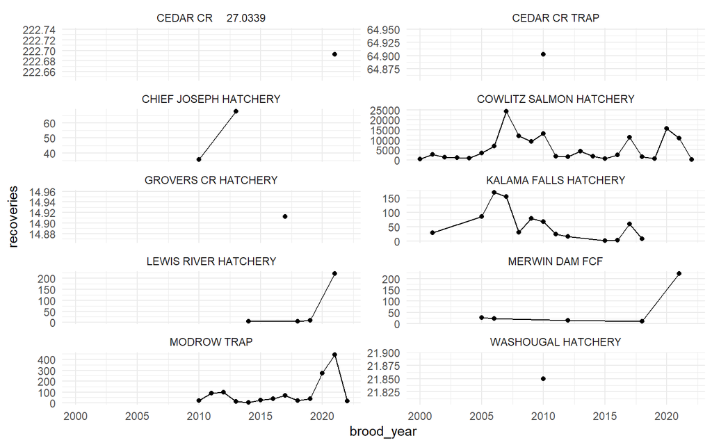

Figure 3: CWT recoveries collected in hatchery operations (rack + weirs) by brood year expanded by tag-rate.

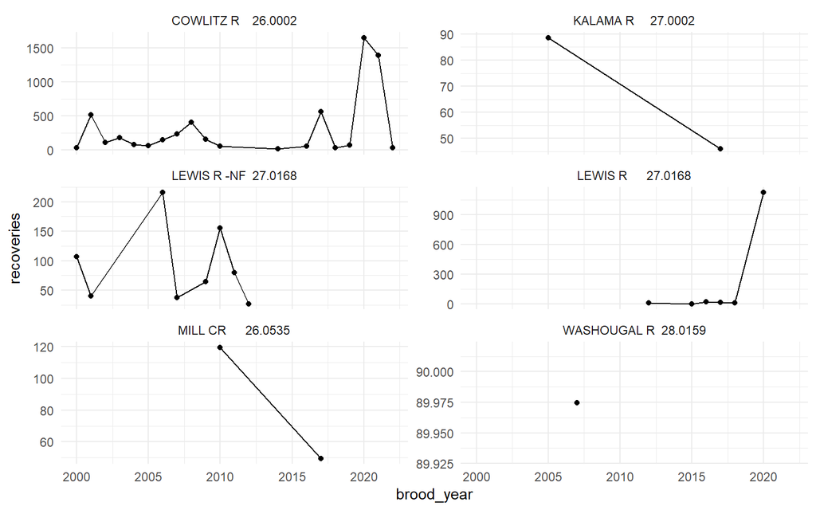

Figure 4: CWT recoveries collected on spawning grounds by brood year expanded by tag-rate.

**CR_fishery Rec**

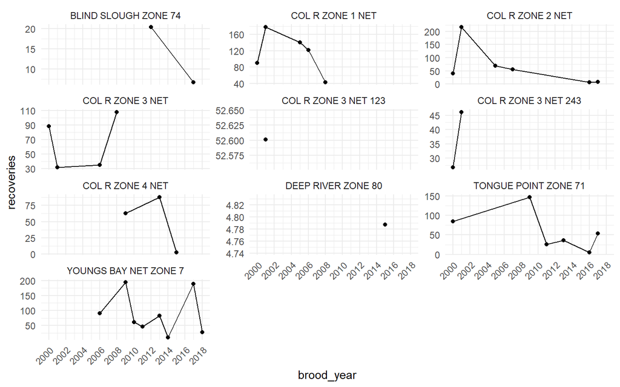

Figure 5: CWT recoveries collected in Columbia River gillnet fisheries by brood year expanded by tag-rate.

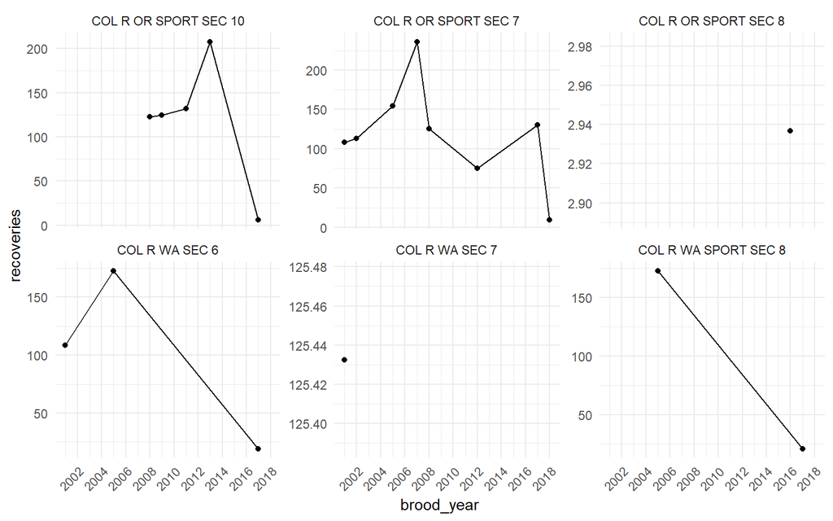

Figure 6: CWT recoveries collected in Columbia River sport fisheries by brood year expanded by tag-rate.

**Est_Fresh Sport Rec**

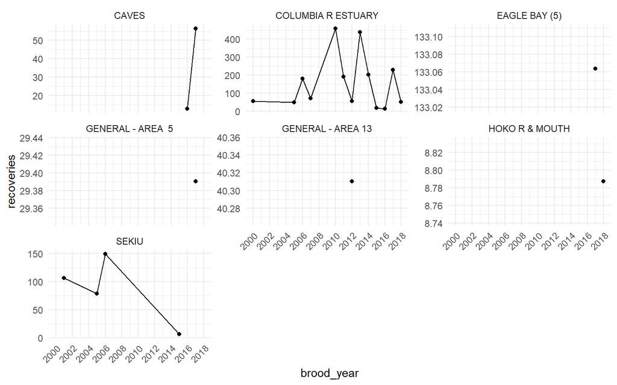

Figure 7: CWT recoveries collected in estuary sport fisheries by brood year expanded by tag-rate.

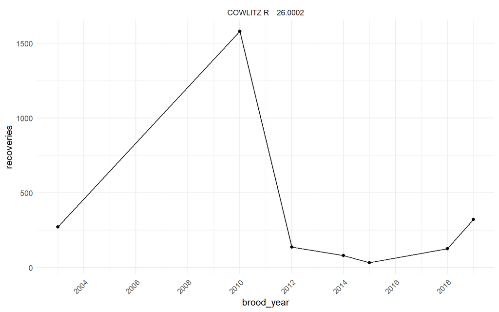

Figure 8: CWT recoveries collected in freshwater sport fisheries by brood year expanded by tag-rate.

**TagRate_Expansion**

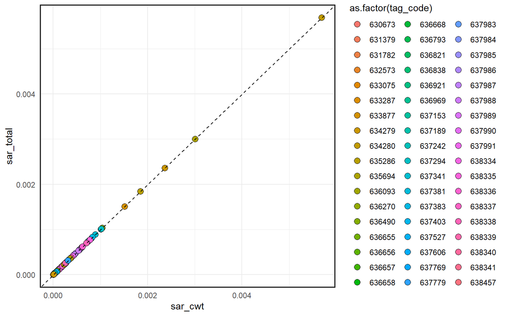

Figure 9: CWT SAR vs. Tag Rate-Expanded SAR by brood year and tag code.

**Hatchery SAR Figures**

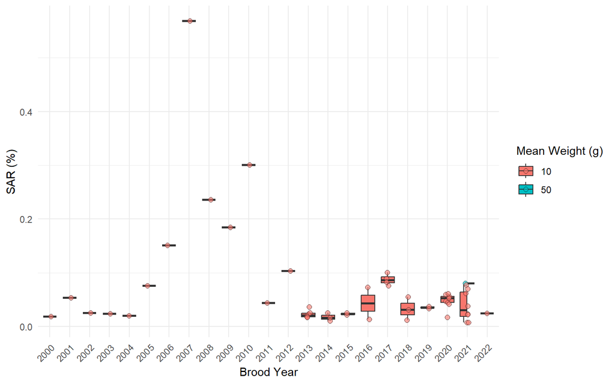

Figure 10: Smolt-adult return calcualted from the raw release and return data across brood years and mean weight release groups.

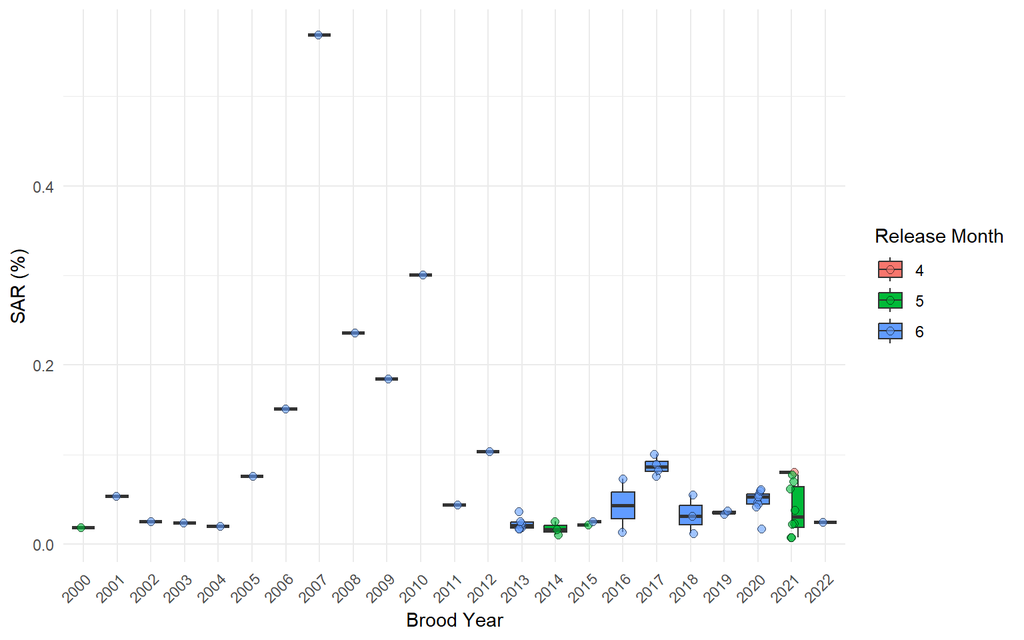

Figure 11: Smolt-adult return calcualted from the raw release and return data across brood years and release month.

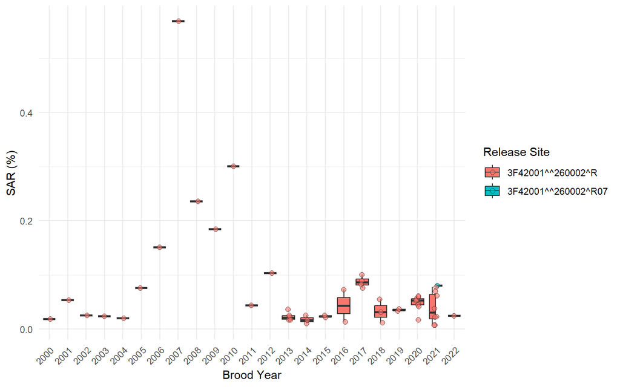

Figure 12: Smolt-adult return calcualted from the raw release and return data across brood years and release sites.

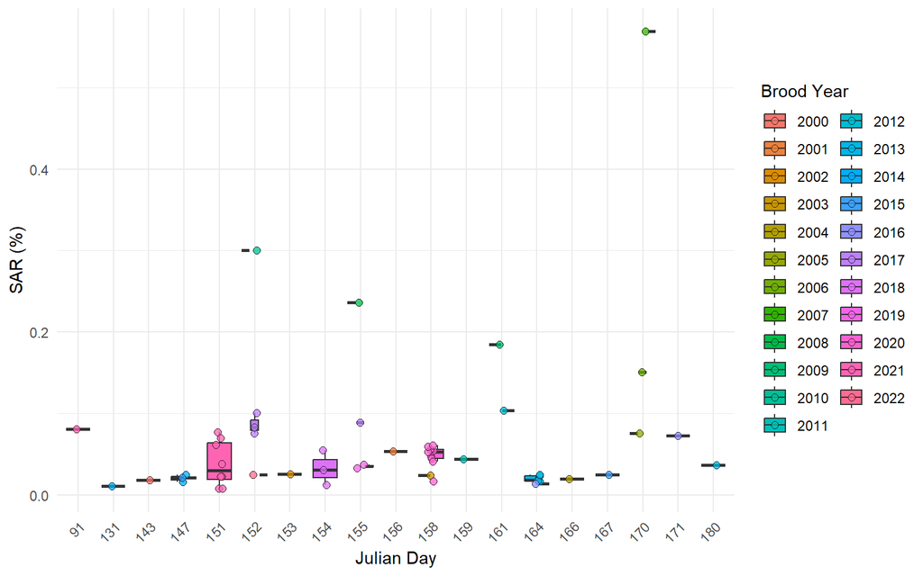

Figure 13: Smolt-adult return calcualted from the raw release and return data across brood years and julian days.

**Spawngr SAR Figures**

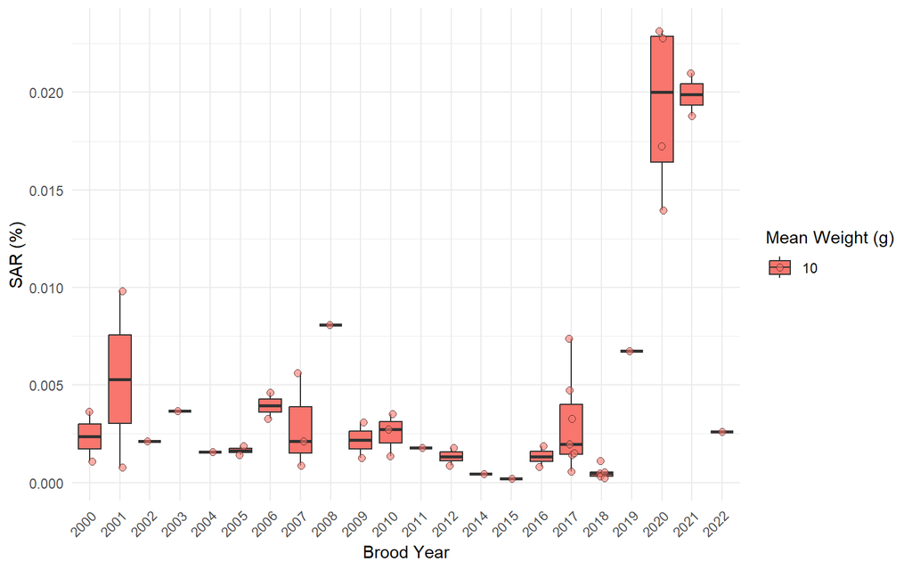

Figure 14: Smolt-adult return calcualted from the raw release and return data across brood years and mean weight release groups.

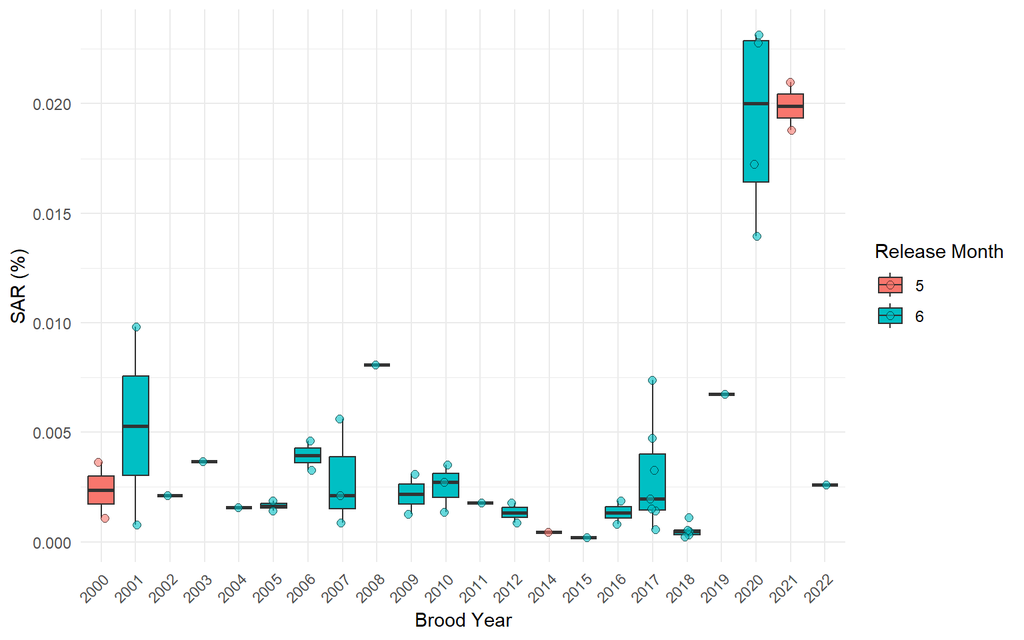

Figure 15: Smolt-adult return calcualted from the raw release and return data across brood years and release month.

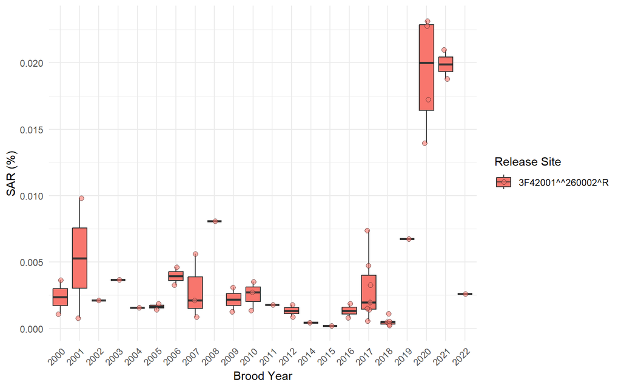

Figure 16: Smolt-adult return calcualted from the raw release and return data across brood years and release sites.

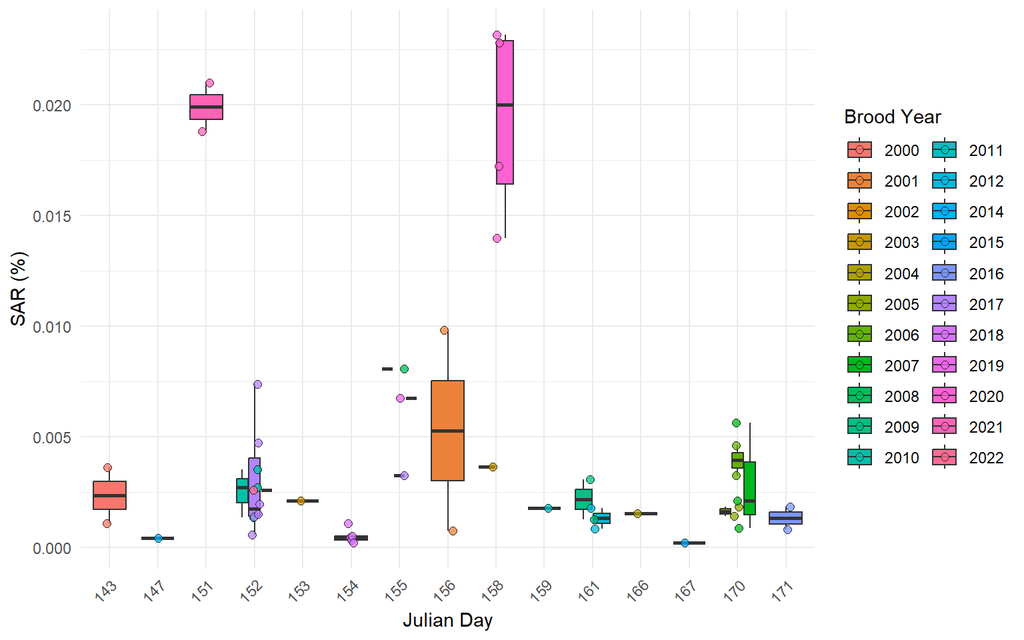

Figure 17: Smolt-adult return calcualted from the raw release and return data across brood years and julian days.

**Fishery SAR Figures**

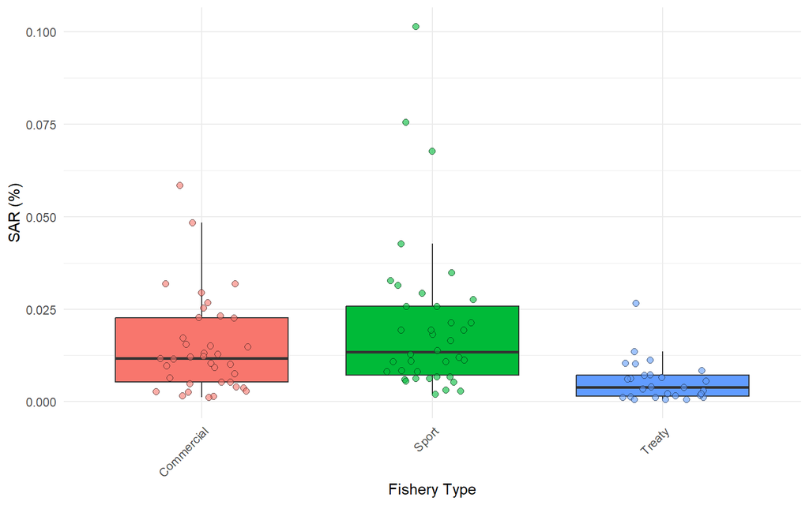

Figure 18: Smolt-adult return calcualted for each fishery type.

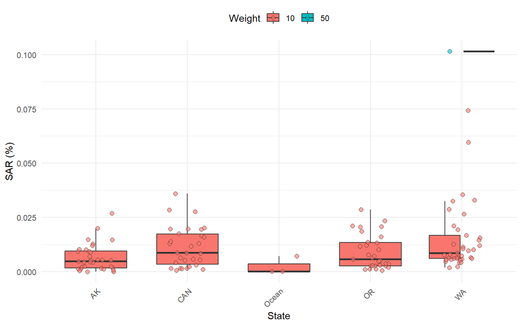

Figure 19: Smolt-adult return calcualted by state landed

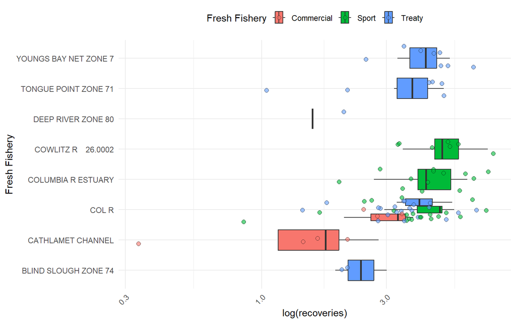

Figure 20: Log of estimated recoveries for freshwater fisheries.

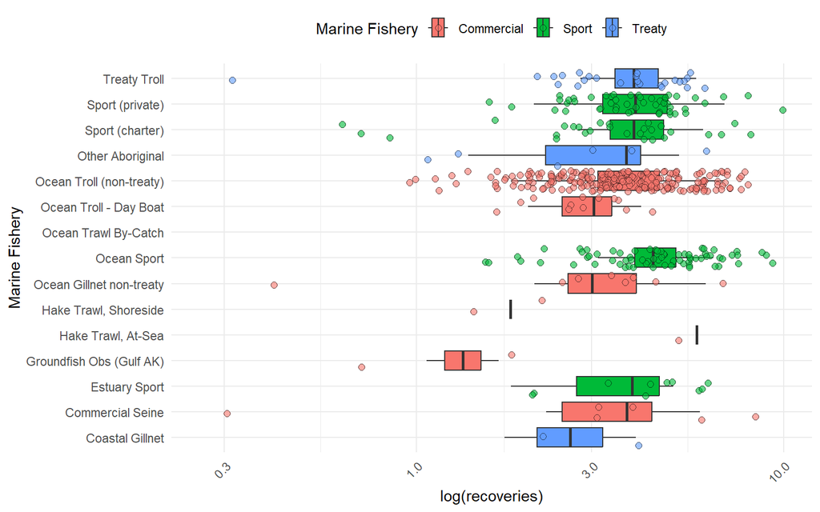

Figure 21: Log of estimated recoveries for marine fisheries.

**Hatchery SAR table**

Table 9: Smolt-adult return calculated across brood years, mean weight-at-release, and time at release for hatchery fates.

| species | release_location_code | recovery_location_code | month | jday | avg_weight | releases | sar |
| --- | --- | --- | --- | --- | --- | --- | --- |
| **2000** |  |  |  |  |  |  |  |
| 1 | 3F42001^^260002^R | 3F42001^^260002^H02 | 5 | 143 | 10 | 2950883 | 0.0187634 |
| **2001** |  |  |  |  |  |  |  |
| 1 | 3F42001^^260002^R | 3F42001^^260002^H02 | 6 | 156 | 10 | 5303871 | 0.0536303 |
| **2002** |  |  |  |  |  |  |  |
| 1 | 3F42001^^260002^R | 3F42001^^260002^H02 | 6 | 153 | 10 | 5215558 | 0.0257677 |
| **2003** |  |  |  |  |  |  |  |
| 1 | 3F42001^^260002^R | 3F42001^^260002^H02 | 6 | 158 | 10 | 5016495 | 0.0241200 |
| **2004** |  |  |  |  |  |  |  |
| 1 | 3F42001^^260002^R | 3F42001^^260002^H02 | 6 | 166 | 10 | 5201338 | 0.0199143 |
| **2005** |  |  |  |  |  |  |  |
| 1 | 3F42001^^260002^R | 3F42001^^260002^H02 | 6 | 170 | 10 | 4758152 | 0.0759407 |
| **2006** |  |  |  |  |  |  |  |
| 1 | 3F42001^^260002^R | 3F42001^^260002^H02 | 6 | 170 | 10 | 4678192 | 0.1510484 |
| **2007** |  |  |  |  |  |  |  |
| 1 | 3F42001^^260002^R | 3F42001^^260002^H02 | 6 | 170 | 10 | 4246647 | 0.5688066 |
| **2008** |  |  |  |  |  |  |  |
| 1 | 3F42001^^260002^R | 3F42001^^260002^H02 | 6 | 155 | 10 | 5104829 | 0.2362376 |
| **2009** |  |  |  |  |  |  |  |
| 1 | 3F42001^^260002^R | 3F42001^^260002^H02 | 6 | 161 | 10 | 5077356 | 0.1844561 |
| **2010** |  |  |  |  |  |  |  |
| 1 | 3F42001^^260002^R | 3F42001^^260002^H02 | 6 | 152 | 10 | 4405456 | 0.3005510 |
| **2011** |  |  |  |  |  |  |  |
| 1 | 3F42001^^260002^R | 3F42001^^260002^H02 | 6 | 159 | 10 | 4494944 | 0.0439527 |
| **2012** |  |  |  |  |  |  |  |
| 1 | 3F42001^^260002^R | 3F42001^^260002^H02 | 6 | 161 | 10 | 1519271 | 0.1035022 |
| **2013** |  |  |  |  |  |  |  |
| 1 | 3F42001^^260002^R | 3F42001^^260002^H02 | 6 | 180 | 10 | 3153131 | 0.0367836 |
| 1 | 3F42001^^260002^R | 3F42001^^260002^H02 | 6 | 164 | 10 | 3153131 | 0.0186298 |
| 1 | 3F42001^^260002^R | 3F42001^^260002^H02 | 6 | 164 | 10 | 3153131 | 0.0173693 |
| 1 | 3F42001^^260002^R | 3F42001^^260002^H02 | 6 | 164 | 10 | 3153131 | 0.0233235 |
| 1 | 3F42001^^260002^R | 3F42001^^260002^H02 | 6 | 164 | 10 | 3153131 | 0.0175648 |
| 1 | 3F42001^^260002^R | 3F42001^^260002^H02 | 6 | 164 | 10 | 3153131 | 0.0251218 |
| **2014** |  |  |  |  |  |  |  |
| 1 | 3F42001^^260002^R | 3F42001^^260002^H02 | 5 | 131 | 10 | 3447633 | 0.0109447 |
| 1 | 3F42001^^260002^R | 3F42001^^260002^H02 | 5 | 147 | 10 | 3447633 | 0.0162969 |
| 1 | 3F42001^^260002^R | 3F42001^^260002^H02 | 5 | 147 | 10 | 3447633 | 0.0252741 |
| **2015** |  |  |  |  |  |  |  |
| 1 | 3F42001^^260002^R | 3F42001^^260002^H02 | 5 | 147 | 10 | 1894965 | 0.0214767 |
| 1 | 3F42001^^260002^R | 3F42001^^260002^H02 | 6 | 167 | 10 | 1521124 | 0.0254597 |
| **2016** |  |  |  |  |  |  |  |
| 1 | 3F42001^^260002^R | 3F42001^^260002^H02 | 6 | 164 | 10 | 2894928 | 0.0138224 |
| 1 | 3F42001^^260002^R | 3F42001^^260002^H02 | 6 | 171 | 10 | 2894928 | 0.0732332 |
| **2017** |  |  |  |  |  |  |  |
| 1 | 3F42001^^260002^R | 3F42001^^260002^H02 | 6 | 152 | 10 | 3274631 | 0.0761230 |
| 1 | 3F42001^^260002^R | 3F42001^^260002^H02 | 6 | 155 | 10 | 3274631 | 0.0893615 |
| 1 | 3F42001^^260002^R | 3F42001^^260002^H02 | 6 | 152 | 10 | 3274631 | 0.0831099 |
| 1 | 3F42001^^260002^R | 3F42001^^260002^H02 | 6 | 152 | 10 | 3274631 | 0.1009424 |
| **2018** |  |  |  |  |  |  |  |
| 1 | 3F42001^^260002^R | 3F42001^^260002^H02 | 6 | 154 | 10 | 1755813 | 0.0123051 |
| 1 | 3F42001^^260002^R | 3F42001^^260002^H02 | 6 | 154 | 10 | 1755813 | 0.0313026 |
| 1 | 3F42001^^260002^R | 3F42001^^260002^H02 | 6 | 154 | 10 | 1755813 | 0.0550174 |
| **2019** |  |  |  |  |  |  |  |
| 1 | 3F42001^^260002^R | 3F42001^^260002^H02 | 6 | 155 | 10 | 1023762 | 0.0334270 |
| 1 | 3F42001^^260002^R | 3F42001^^260002^H02 | 6 | 155 | 10 | 1023762 | 0.0373522 |
| **2020** |  |  |  |  |  |  |  |
| 1 | 3F42001^^260002^R | 3F42001^^260002^H02 | 6 | 158 | 10 | 3596659 | 0.0171542 |
| 1 | 3F42001^^260002^R | 3F42001^^260002^H02 | 6 | 158 | 10 | 3596659 | 0.0544487 |
| 1 | 3F42001^^260002^R | 3F42001^^260002^H02 | 6 | 158 | 10 | 3596659 | 0.0561316 |
| 1 | 3F42001^^260002^R | 3F42001^^260002^H02 | 6 | 158 | 10 | 3596659 | 0.0472828 |
| 1 | 3F42001^^260002^R | 3F42001^^260002^H02 | 6 | 158 | 10 | 3596659 | 0.0451426 |
| 1 | 3F42001^^260002^R | 3F42001^^260002^H02 | 6 | 158 | 10 | 3596659 | 0.0531663 |
| 1 | 3F42001^^260002^R | 3F42001^^260002^H02 | 6 | 158 | 10 | 3596659 | 0.0600136 |
| 1 | 3F42001^^260002^R | 3F42001^^260002^H02 | 6 | 158 | 10 | 3596659 | 0.0416097 |
| 1 | 3F42001^^260002^R | 3F42001^^260002^H02 | 6 | 158 | 10 | 3596659 | 0.0615004 |
| **2021** |  |  |  |  |  |  |  |
| 1 | 3F42001^^260002^R07 | 3F42001^^260002^H02 | 4 | 91 | 50 | 19482 | 0.0806878 |
| 1 | 3F42001^^260002^R | 3F42001^^260002^H02 | 5 | 151 | 10 | 3503839 | 0.0078655 |
| 1 | 3F42001^^260002^R | 3F42001^^260002^H02 | 5 | 151 | 10 | 3503839 | 0.0776895 |
| 1 | 3F42001^^260002^R | 3F42001^^260002^H02 | 5 | 151 | 10 | 3503839 | 0.0622307 |
| 1 | 3F42001^^260002^R | 3F42001^^260002^H02 | 5 | 151 | 10 | 3503839 | 0.0229085 |
| 1 | 3F42001^^260002^R | 3F42001^^260002^H02 | 5 | 151 | 10 | 3503839 | 0.0701665 |
| 1 | 3F42001^^260002^R | 3F42001^^260002^H02 | 5 | 151 | 10 | 3503839 | 0.0226196 |
| 1 | 3F42001^^260002^R | 3F42001^^260002^H02 | 5 | 151 | 10 | 3503839 | 0.0383350 |
| 1 | 3F42001^^260002^R | 3F42001^^260002^H02 | 5 | 151 | 10 | 3503839 | 0.0078397 |
| **2022** |  |  |  |  |  |  |  |
| 1 | 3F42001^^260002^R | 3F42001^^260002^H02 | 6 | 152 | 10 | 1187707 | 0.0247874 |

**Spawngr SAR Table**

Table 10: Smolt-adult return calculated across brood years, mean weight-at-release, and time at release for spawngr fates.

| species | release_location_code | recovery_location_code | month | jday | avg_weight | releases | sar |
| --- | --- | --- | --- | --- | --- | --- | --- |
| **2000** |  |  |  |  |  |  |  |
| 1 | 3F42001^^260002^R | 3F42001^^260002^R | 5 | 143 | 10 | 2950883 | 0.0010943 |
| 1 | 3F42001^^260002^R | 3F42001^^270168^R01 | 5 | 143 | 10 | 2950883 | 0.0036377 |
| **2001** |  |  |  |  |  |  |  |
| 1 | 3F42001^^260002^R | 3F42001^^260002^R | 6 | 156 | 10 | 5303871 | 0.0098125 |
| 1 | 3F42001^^260002^R | 3F42001^^270168^R01 | 6 | 156 | 10 | 5303871 | 0.0007629 |
| **2002** |  |  |  |  |  |  |  |
| 1 | 3F42001^^260002^R | 3F42001^^260002^R | 6 | 153 | 10 | 5215558 | 0.0021186 |
| **2003** |  |  |  |  |  |  |  |
| 1 | 3F42001^^260002^R | 3F42001^^260002^R | 6 | 158 | 10 | 5016495 | 0.0036666 |
| **2004** |  |  |  |  |  |  |  |
| 1 | 3F42001^^260002^R | 3F42001^^260002^R | 6 | 166 | 10 | 5201338 | 0.0015611 |
| **2005** |  |  |  |  |  |  |  |
| 1 | 3F42001^^260002^R | 3F42001^^260002^R | 6 | 170 | 10 | 4758152 | 0.0014184 |
| 1 | 3F42001^^260002^R | 3F42001^^270002^R | 6 | 170 | 10 | 4758152 | 0.0018612 |
| **2006** |  |  |  |  |  |  |  |
| 1 | 3F42001^^260002^R | 3F42001^^260002^R | 6 | 170 | 10 | 4678192 | 0.0032754 |
| 1 | 3F42001^^260002^R | 3F42001^^270168^R01 | 6 | 170 | 10 | 4678192 | 0.0046113 |
| **2007** |  |  |  |  |  |  |  |
| 1 | 3F42001^^260002^R | 3F42001^^260002^R | 6 | 170 | 10 | 4246647 | 0.0056269 |
| 1 | 3F42001^^260002^R | 3F42001^^270168^R01 | 6 | 170 | 10 | 4246647 | 0.0008771 |
| 1 | 3F42001^^260002^R | 3F42001^^280159^R | 6 | 170 | 10 | 4246647 | 0.0021187 |
| **2008** |  |  |  |  |  |  |  |
| 1 | 3F42001^^260002^R | 3F42001^^260002^R | 6 | 155 | 10 | 5104829 | 0.0080764 |
| **2009** |  |  |  |  |  |  |  |
| 1 | 3F42001^^260002^R | 3F42001^^260002^R | 6 | 161 | 10 | 5077356 | 0.0030835 |
| 1 | 3F42001^^260002^R | 3F42001^^270168^R01 | 6 | 161 | 10 | 5077356 | 0.0012658 |
| **2010** |  |  |  |  |  |  |  |
| 1 | 3F42001^^260002^R | 3F42001^^260002^R | 6 | 152 | 10 | 4405456 | 0.0013554 |
| 1 | 3F42001^^260002^R | 3F42001^^260535^R | 6 | 152 | 10 | 4405456 | 0.0027107 |
| 1 | 3F42001^^260002^R | 3F42001^^270168^R01 | 6 | 152 | 10 | 4405456 | 0.0035308 |
| **2011** |  |  |  |  |  |  |  |
| 1 | 3F42001^^260002^R | 3F42001^^270168^R01 | 6 | 159 | 10 | 4494944 | 0.0017764 |
| **2012** |  |  |  |  |  |  |  |
| 1 | 3F42001^^260002^R | 3F42001^^270168^R | 6 | 161 | 10 | 1519271 | 0.0008694 |
| 1 | 3F42001^^260002^R | 3F42001^^270168^R01 | 6 | 161 | 10 | 1519271 | 0.0017838 |
| **2014** |  |  |  |  |  |  |  |
| 1 | 3F42001^^260002^R | 3F42001^^260002^R | 5 | 147 | 10 | 3447633 | 0.0004447 |
| **2015** |  |  |  |  |  |  |  |
| 1 | 3F42001^^260002^R | 3F42001^^270168^R | 6 | 167 | 10 | 1521124 | 0.0002086 |
| **2016** |  |  |  |  |  |  |  |
| 1 | 3F42001^^260002^R | 3F42001^^260002^R | 6 | 171 | 10 | 2894928 | 0.0018602 |
| 1 | 3F42001^^260002^R | 3F42001^^270168^R | 6 | 171 | 10 | 2894928 | 0.0008106 |
| **2017** |  |  |  |  |  |  |  |
| 1 | 3F42001^^260002^R | 3F42001^^260002^R | 6 | 152 | 10 | 3274631 | 0.0019764 |
| 1 | 3F42001^^260002^R | 3F42001^^270002^R | 6 | 152 | 10 | 3274631 | 0.0014026 |
| 1 | 3F42001^^260002^R | 3F42001^^260002^R | 6 | 155 | 10 | 3274631 | 0.0032737 |
| 1 | 3F42001^^260002^R | 3F42001^^260002^R | 6 | 152 | 10 | 3274631 | 0.0073807 |
| 1 | 3F42001^^260002^R | 3F42001^^260535^R | 6 | 152 | 10 | 3274631 | 0.0015111 |
| 1 | 3F42001^^260002^R | 3F42001^^260002^R | 6 | 152 | 10 | 3274631 | 0.0047349 |
| 1 | 3F42001^^260002^R | 3F42001^^270168^R | 6 | 152 | 10 | 3274631 | 0.0005742 |
| **2018** |  |  |  |  |  |  |  |
| 1 | 3F42001^^260002^R | 3F42001^^260002^R | 6 | 154 | 10 | 1755813 | 0.0011014 |
| 1 | 3F42001^^260002^R | 3F42001^^260002^R | 6 | 154 | 10 | 1755813 | 0.0004759 |
| 1 | 3F42001^^260002^R | 3F42001^^270168^R | 6 | 154 | 10 | 1755813 | 0.0003290 |
| 1 | 3F42001^^260002^R | 3F42001^^260002^R | 6 | 154 | 10 | 1755813 | 0.0005308 |
| 1 | 3F42001^^260002^R | 3F42001^^270168^R | 6 | 154 | 10 | 1755813 | 0.0002275 |
| **2019** |  |  |  |  |  |  |  |
| 1 | 3F42001^^260002^R | 3F42001^^260002^R | 6 | 155 | 10 | 1023762 | 0.0067458 |
| **2020** |  |  |  |  |  |  |  |
| 1 | 3F42001^^260002^R | 3F42001^^260002^R | 6 | 158 | 10 | 3596659 | 0.0231543 |
| 1 | 3F42001^^260002^R | 3F42001^^260002^R | 6 | 158 | 10 | 3596659 | 0.0227971 |
| 1 | 3F42001^^260002^R | 3F42001^^270168^R | 6 | 158 | 10 | 3596659 | 0.0172335 |
| 1 | 3F42001^^260002^R | 3F42001^^270168^R | 6 | 158 | 10 | 3596659 | 0.0139711 |
| **2021** |  |  |  |  |  |  |  |
| 1 | 3F42001^^260002^R | 3F42001^^260002^R | 5 | 151 | 10 | 3503839 | 0.0187951 |
| 1 | 3F42001^^260002^R | 3F42001^^260002^R | 5 | 151 | 10 | 3503839 | 0.0210020 |
| **2022** |  |  |  |  |  |  |  |
| 1 | 3F42001^^260002^R | 3F42001^^260002^R | 6 | 152 | 10 | 1187707 | 0.0025944 |

**Fishery SAR Table**

Table 11: Smolt-adult return calculated across brood years, mean weight-at-release, and time at release for fishery fates.

| species | release_location_code | recovery_location_code | month | jday | avg_weight | releases | sar |
| --- | --- | --- | --- | --- | --- | --- | --- |
| **2000** |  |  |  |  |  |  |  |
| 1 | 3F42001^^260002^R | 5F33209^^R1^^^^^13 | 5 | 143 | 10 | 2950883 | 0.0030681 |
| 1 | 3F42001^^260002^R | 5F33209^^R2^^^^^13 | 5 | 143 | 10 | 2950883 | 0.0013741 |
| 1 | 3F42001^^260002^R | 5F33209^^R243^^^13 | 5 | 143 | 10 | 2950883 | 0.0009094 |
| 1 | 3F42001^^260002^R | 5F33209^^R3^^^^^13 | 5 | 143 | 10 | 2950883 | 0.0030031 |
| 1 | 3F42001^^260002^R | 5F33271^^R71^^^^13 | 5 | 143 | 10 | 2950883 | 0.0028882 |
| 1 | 3F42001^^260002^R | 5F33201^^R1^^^^^32 | 5 | 143 | 10 | 2950883 | 0.0019488 |
| 1 | 3F42001^^260002^R | 5M2220201O0201^^10 | 5 | 143 | 10 | 2950883 | 0.0035878 |
| 1 | 3F42001^^260002^R | 5M2221003O1003^^10 | 5 | 143 | 10 | 2950883 | 0.0011743 |
| 1 | 3F42001^^260002^R | 5M2222404O2404^^10 | 5 | 143 | 10 | 2950883 | 0.0030931 |
| 1 | 3F42001^^260002^R | 1M1NW113^41 | 5 | 143 | 10 | 2950883 | 0.0015590 |
| 1 | 3F42001^^260002^R | 1M1NW154 | 5 | 143 | 10 | 2950883 | 0.0017189 |
| 1 | 3F42001^^260002^R | 1M1SW104^40 | 5 | 143 | 10 | 2950883 | 0.0009994 |
| 1 | 3F42001^^260002^R | 2MN06H001^^^^^^^200 | 5 | 143 | 10 | 2950883 | 0.0009494 |
| 1 | 3F42001^^260002^R | 2MS02H023^^^^^^^058 | 5 | 143 | 10 | 2950883 | 0.0013791 |
| 1 | 3F42001^^260002^R | 3M32202 | 5 | 143 | 10 | 2950883 | 0.0005946 |
| 1 | 3F42001^^260002^R | 3M32202 | 5 | 143 | 10 | 2950883 | 0.0011143 |
| 1 | 3F42001^^260002^R | 3M32202 | 5 | 143 | 10 | 2950883 | 0.0017439 |
| 1 | 3F42001^^260002^R | 3M32404 | 5 | 143 | 10 | 2950883 | 0.0012442 |
| **2001** |  |  |  |  |  |  |  |
| 1 | 3F42001^^260002^R | 5F33209^^R1^^^^^13 | 6 | 156 | 10 | 5303871 | 0.0033519 |
| 1 | 3F42001^^260002^R | 5F33209^^R123^^^13 | 6 | 156 | 10 | 5303871 | 0.0009917 |
| 1 | 3F42001^^260002^R | 5F33209^^R2^^^^^13 | 6 | 156 | 10 | 5303871 | 0.0040766 |
| 1 | 3F42001^^260002^R | 5F33209^^R243^^^13 | 6 | 156 | 10 | 5303871 | 0.0008678 |
| 1 | 3F42001^^260002^R | 5F33209^^R3^^^^^13 | 6 | 156 | 10 | 5303871 | 0.0005960 |
| 1 | 3F42001^^260002^R | 5F33203^^R106^^^12 | 6 | 156 | 10 | 5303871 | 0.0020407 |
| 1 | 3F42001^^260002^R | 5F33203^^R107^^^12 | 6 | 156 | 10 | 5303871 | 0.0023649 |
| 1 | 3F42001^^260002^R | 5F33203^^R207^^^12 | 6 | 156 | 10 | 5303871 | 0.0020407 |
| 1 | 3F42001^^260002^R | 1M1SWSASO | 6 | 156 | 10 | 5303871 | 0.0070280 |
| 1 | 3F42001^^260002^R | 3M11105^^872465 | 6 | 156 | 10 | 5303871 | 0.0020026 |

[output cut: 601 more lines]

SAR Model Fit

Smolt-adult survival (SAS) represents the survival of a release group when considering all of their possible fates. The performance of a program will depend on how well the intended fate of those fish matches up with the observed proportion-at-fate. Here, we take release and return data from above and use these data collectively to calculate SAS as the number of fish that were recovered divided by the number released. Further work is needed to incorporate strays into this calculation.

| Component | Term | Estimate | Std Error | t-value | p-value |  |
| --- | --- | --- | --- | --- | --- | --- |
| A. parametric coefficients | (Intercept) | -10.773 | 0.165 | -65.472 | 0.0000 | *** |
|  | fatehatchery | 2.909 | 0.190 | 15.348 | 0.0000 | *** |
|  | fatespawngr | 0.735 | 0.424 | 1.736 | 0.0867 | . |
| Component | Term | edf | Ref. df | F-value | p-value |  |
| B. smooth terms | te(jday,brood_year) | 2.868 | 19.000 | 1.134 | 0.0001 | *** |

Signif. codes: 0 <= '***' < 0.001 < '**' < 0.01 < '*' < 0.05  
Adjusted R-squared: 0.428, Deviance explained 0.775  
-REML : -313.427, Scale est: 1255.983, N: 80

**Predicted SAR**

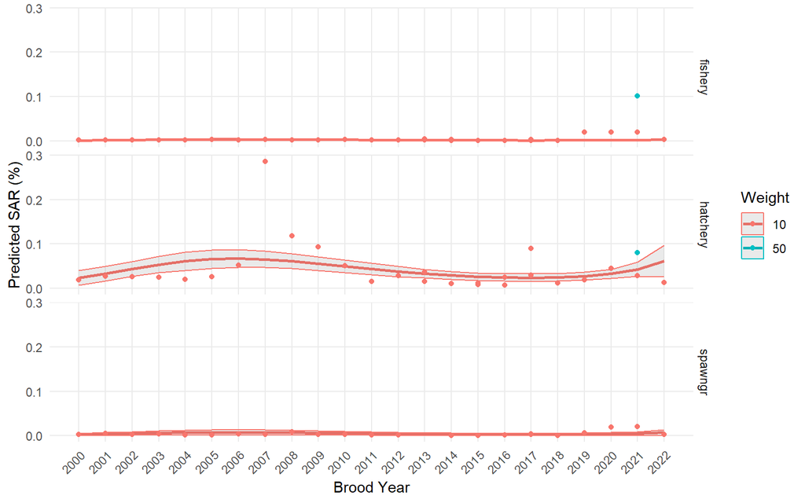

**Observed:Predicted**

[interactive chart not shown]

Figure 23: Raw-calculated vs. Model-predicted smolt-adult return generated from the model fit.

**Marginal Effects**

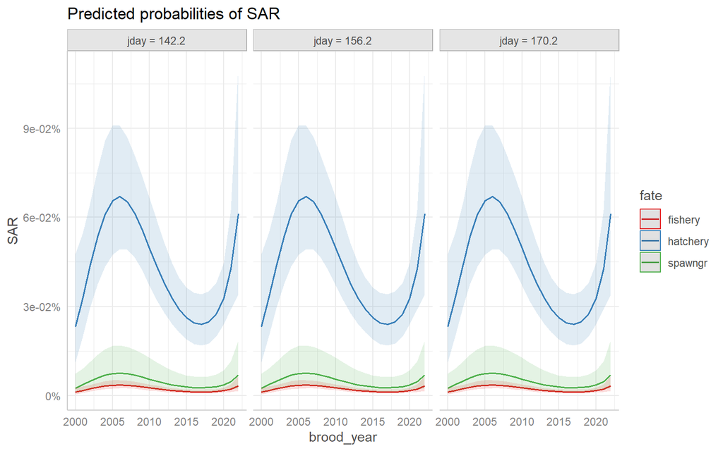

**Proportion-at-fate**

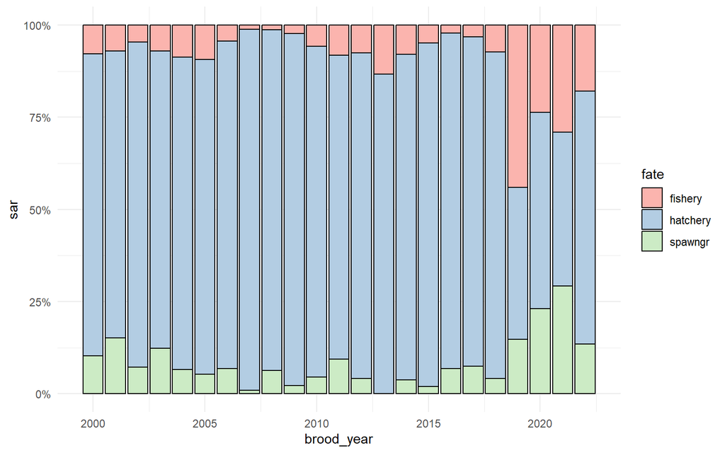

Figure 25: Proportion-at-fate of the calculated smolt-adult-return across brood years.

**SAS**

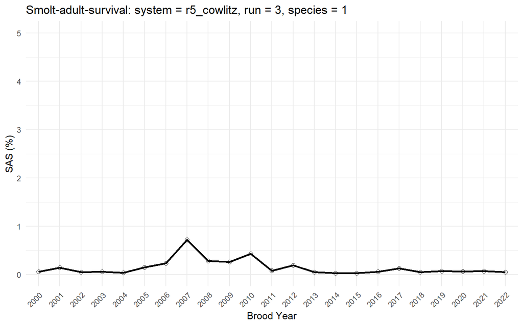